# ExtraaLearn Project

## Context

The EdTech industry has been surging in the past decade immensely, and according to a forecast, the Online Education market would be worth $286.62bn by 2023 with a compound annual growth rate (CAGR) of 10.26% from 2018 to 2023. The modern era of online education has enforced a lot in its growth and expansion beyond any limit. Due to having many dominant features like ease of information sharing, personalized learning experience, transparency of assessment, etc, it is now preferable to traditional education.

In the present scenario due to the Covid-19, the online education sector has witnessed rapid growth and is attracting a lot of new customers. Due to this rapid growth, many new companies have emerged in this industry. With the availability and ease of use of digital marketing resources, companies can reach out to a wider audience with their offerings. The customers who show interest in these offerings are termed as leads. There are various sources of obtaining leads for Edtech companies, like

- The customer interacts with the marketing front on social media or other online platforms.
- The customer browses the website/app and downloads the brochure
- The customer connects through emails for more information.

The company then nurtures these leads and tries to convert them to paid customers. For this, the representative from the organization connects with the lead on call or through email to share further details.

## Objective

ExtraaLearn is an initial stage startup that offers programs on cutting-edge technologies to students and professionals to help them upskill/reskill. With a large number of leads being generated on a regular basis, one of the issues faced by ExtraaLearn is to identify which of the leads are more likely to convert so that they can allocate resources accordingly. You, as a data scientist at ExtraaLearn, have been provided the leads data to:

- Analyze and build an ML model to help identify which leads are more likely to convert to paid customers,
- Find the factors driving the lead conversion process
- Create a profile of the leads which are likely to convert

## Data Description

The data contains the different attributes of leads and their interaction details with ExtraaLearn. The detailed data dictionary is given below.

**Data Dictionary**

- ID: ID of the lead
- age: Age of the lead
- current_occupation: Current occupation of the lead. Values include 'Professional','Unemployed',and 'Student'
- first_interaction: How did the lead first interacted with ExtraaLearn. Values include 'Website', 'Mobile App'
- profile_completed: What percentage of profile has been filled by the lead on the website/mobile app. Values include Low - (0-50%), Medium - (50-75%), High (75-100%)
- website_visits: How many times has a lead visited the website
- time_spent_on_website: Total time spent on the website
- page_views_per_visit: Average number of pages on the website viewed during the visits.
- last_activity: Last interaction between the lead and ExtraaLearn.
  - Email Activity: Seeking for details about program through email, Representative shared information with lead like brochure of program , etc
  - Phone Activity: Had a Phone Conversation with representative, Had conversation over SMS with representative, etc
  - Website Activity: Interacted on live chat with representative, Updated profile on website, etc
- print_media_type1: Flag indicating whether the lead had seen the ad of ExtraaLearn in the Newspaper.
- print_media_type2: Flag indicating whether the lead had seen the ad of ExtraaLearn in the Magazine.
- digital_media: Flag indicating whether the lead had seen the ad of ExtraaLearn on the digital platforms.
- educational_channels: Flag indicating whether the lead had heard about ExtraaLearn in the education channels like online forums, discussion threads, educational websites, etc.
- referral: Flag indicating whether the lead had heard about ExtraaLearn through reference.
- status: Flag indicating whether the lead was converted to a paid customer or not.

```python
from google.colab import drive
drive.mount('/content/drive')
```

## Importing necessary libraries and data

```python
# Importing the basic libraries we will require for the project

# Data Readers
import pandas as pd
import numpy as np

# Data visualization
import matplotlib.pyplot as plt
import seaborn as sns
sns.set()
import plotly.express as px

# Machine Learning models from Scikit-Learn
from sklearn.linear_model import LogisticRegression
from sklearn.svm import SVC
from sklearn.tree import DecisionTreeClassifier
from sklearn import tree
from sklearn.ensemble import RandomForestClassifier

# Other functions from Scikit-Learn
from sklearn.model_selection import train_test_split, GridSearchCV
from sklearn.preprocessing import MinMaxScaler, LabelEncoder, OneHotEncoder
from sklearn.impute import SimpleImputer
from sklearn.preprocessing import StandardScaler

# Get diferent metric scores
from sklearn.metrics import confusion_matrix,classification_report,roc_auc_score,precision_recall_curve,roc_curve,make_scorer
from sklearn.metrics import accuracy_score
# Ignore warnings from function usage
import warnings;
import numpy as np
warnings.filterwarnings('ignore')
```

## Data Overview

- Observations
- Sanity checks

```python
#Load Data Set
df=pd.read_csv('/content/drive/MyDrive/Classification and Hypothesis Testing Project/ExtraaLearn.csv')

#Start review of Data
#Show first 5 rows of data
df.head()
```

|  | ID | age | current_occupation | first_interaction | profile_completed | website_visits | time_spent_on_website | page_views_per_visit | last_activity | print_media_type1 | print_media_type2 | digital_media | educational_channels | referral | status |
| --- | --- | --- | --- | --- | --- | --- | --- | --- | --- | --- | --- | --- | --- | --- | --- |
| 0 | EXT001 | 57 | Unemployed | Website | High | 7 | 1639 | 1.861 | Website Activity | Yes | No | Yes | No | No | 1 |
| 1 | EXT002 | 56 | Professional | Mobile App | Medium | 2 | 83 | 0.320 | Website Activity | No | No | No | Yes | No | 0 |
| 2 | EXT003 | 52 | Professional | Website | Medium | 3 | 330 | 0.074 | Website Activity | No | No | Yes | No | No | 0 |
| 3 | EXT004 | 53 | Unemployed | Website | High | 4 | 464 | 2.057 | Website Activity | No | No | No | No | No | 1 |
| 4 | EXT005 | 23 | Student | Website | High | 4 | 600 | 16.914 | Email Activity | No | No | No | No | No | 0 |

```python
#Show last 5 rows of data
df.tail()
```

|  | ID | age | current_occupation | first_interaction | profile_completed | website_visits | time_spent_on_website | page_views_per_visit | last_activity | print_media_type1 | print_media_type2 | digital_media | educational_channels | referral | status |
| --- | --- | --- | --- | --- | --- | --- | --- | --- | --- | --- | --- | --- | --- | --- | --- |
| 4607 | EXT4608 | 35 | Unemployed | Mobile App | Medium | 15 | 360 | 2.170 | Phone Activity | No | No | No | Yes | No | 0 |
| 4608 | EXT4609 | 55 | Professional | Mobile App | Medium | 8 | 2327 | 5.393 | Email Activity | No | No | No | No | No | 0 |
| 4609 | EXT4610 | 58 | Professional | Website | High | 2 | 212 | 2.692 | Email Activity | No | No | No | No | No | 1 |
| 4610 | EXT4611 | 57 | Professional | Mobile App | Medium | 1 | 154 | 3.879 | Website Activity | Yes | No | No | No | No | 0 |
| 4611 | EXT4612 | 55 | Professional | Website | Medium | 4 | 2290 | 2.075 | Phone Activity | No | No | No | No | No | 0 |

```python
# Compare data shape to what I see.  I should have 4612 rows and 15 columns
df.shape
```

```
(4612, 15)
```

```python
#Check Data Types
df.info()
```

```
<class 'pandas.core.frame.DataFrame'>
RangeIndex: 4612 entries, 0 to 4611
Data columns (total 15 columns):
 #   Column                 Non-Null Count  Dtype
---  ------                 --------------  -----
 0   ID                     4612 non-null   object
 1   age                    4612 non-null   int64
 2   current_occupation     4612 non-null   object
 3   first_interaction      4612 non-null   object
 4   profile_completed      4612 non-null   object
 5   website_visits         4612 non-null   int64
 6   time_spent_on_website  4612 non-null   int64
 7   page_views_per_visit   4612 non-null   float64
 8   last_activity          4612 non-null   object
 9   print_media_type1      4612 non-null   object
 10  print_media_type2      4612 non-null   object
 11  digital_media          4612 non-null   object
 12  educational_channels   4612 non-null   object
 13  referral               4612 non-null   object
 14  status                 4612 non-null   int64
dtypes: float64(1), int64(4), object(10)
memory usage: 540.6+ KB
```

```python
#data looks good from standpoint of no missing values and data types are assigned properly
#check to make sure that all customer ID's are unique and that binary objects only have 2 unique values
df.nunique()
```

```
ID                       4612
age                        46
current_occupation          3
first_interaction           2
profile_completed           3
website_visits             27
time_spent_on_website    1623
page_views_per_visit     2414
last_activity               3
print_media_type1           2
print_media_type2           2
digital_media               2
educational_channels        2
referral                    2
status                      2
dtype: int64
```

```python
#Drop ID Column
df=df.drop(['ID'], axis=1)
```

```python
#Check the count of each unique category in each of the categorical variable
#Create list of numerical features
num_col=['age', 'website_visits', 'time_spent_on_website', 'page_views_per_visit']

#Create list of categorical features
category_col=['current_occupation', 'first_interaction', 'profile_completed', 'last_activity', 'print_media_type1', 'print_media_type2', 'digital_media', 'educational_channels', 'referral', 'status']
```

```python
#Convert data type for each categorical variable to 'category'
for column in category_col:
  df[column]=df[column].astype('category')

df.info()
```

```
<class 'pandas.core.frame.DataFrame'>
RangeIndex: 4612 entries, 0 to 4611
Data columns (total 14 columns):
 #   Column                 Non-Null Count  Dtype
---  ------                 --------------  -----
 0   age                    4612 non-null   int64
 1   current_occupation     4612 non-null   category
 2   first_interaction      4612 non-null   category
 3   profile_completed      4612 non-null   category
 4   website_visits         4612 non-null   int64
 5   time_spent_on_website  4612 non-null   int64
 6   page_views_per_visit   4612 non-null   float64
 7   last_activity          4612 non-null   category
 8   print_media_type1      4612 non-null   category
 9   print_media_type2      4612 non-null   category
 10  digital_media          4612 non-null   category
 11  educational_channels   4612 non-null   category
 12  referral               4612 non-null   category
 13  status                 4612 non-null   category
dtypes: category(10), float64(1), int64(3)
memory usage: 190.5 KB
```

```python
#provide information regarding

df[num_col].describe()
```

|  | age | website_visits | time_spent_on_website | page_views_per_visit |
| --- | --- | --- | --- | --- |
| count | 4612.000000 | 4612.000000 | 4612.000000 | 4612.000000 |
| mean | 46.201214 | 3.566782 | 724.011275 | 3.026126 |
| std | 13.161454 | 2.829134 | 743.828683 | 1.968125 |
| min | 18.000000 | 0.000000 | 0.000000 | 0.000000 |
| 25% | 36.000000 | 2.000000 | 148.750000 | 2.077750 |
| 50% | 51.000000 | 3.000000 | 376.000000 | 2.792000 |
| 75% | 57.000000 | 5.000000 | 1336.750000 | 3.756250 |
| max | 63.000000 | 30.000000 | 2537.000000 | 18.434000 |

```python
df.info()
```

```
<class 'pandas.core.frame.DataFrame'>
RangeIndex: 4612 entries, 0 to 4611
Data columns (total 14 columns):
 #   Column                 Non-Null Count  Dtype
---  ------                 --------------  -----
 0   age                    4612 non-null   int64
 1   current_occupation     4612 non-null   category
 2   first_interaction      4612 non-null   category
 3   profile_completed      4612 non-null   category
 4   website_visits         4612 non-null   int64
 5   time_spent_on_website  4612 non-null   int64
 6   page_views_per_visit   4612 non-null   float64
 7   last_activity          4612 non-null   category
 8   print_media_type1      4612 non-null   category
 9   print_media_type2      4612 non-null   category
 10  digital_media          4612 non-null   category
 11  educational_channels   4612 non-null   category
 12  referral               4612 non-null   category
 13  status                 4612 non-null   category
dtypes: category(10), float64(1), int64(3)
memory usage: 190.5 KB
```

## Exploratory Data Analysis (EDA)

- EDA is an important part of any project involving data.
- It is important to investigate and understand the data better before building a model with it.
- A few questions have been mentioned below which will help you approach the analysis in the right manner and generate insights from the data.
- A thorough analysis of the data, in addition to the questions mentioned below, should be done.

**Questions**

1. Leads will have different expectations from the outcome of the course and the current occupation may play a key role in getting them to participate in the program. Find out how current occupation affects lead status.
2. The company's first impression on the customer must have an impact. Do the first channels of interaction have an impact on the lead status?
3. The company uses multiple modes to interact with prospects. Which way of interaction works best?
4. The company gets leads from various channels such as print media, digital media, referrals, etc. Which of these channels have the highest lead conversion rate?
5. People browsing the website or mobile application are generally required to create a profile by sharing their personal data before they can access additional information.Does having more details about a prospect increase the chances of conversion?

## Data Preprocessing

- Missing value treatment (if needed)
- Feature engineering (if needed)
- Outlier detection and treatment (if needed)
- Preparing data for modeling
- Any other preprocessing steps (if needed)

```python
# Completed above
```

## EDA

- It is a good idea to explore the data once again after manipulating it.

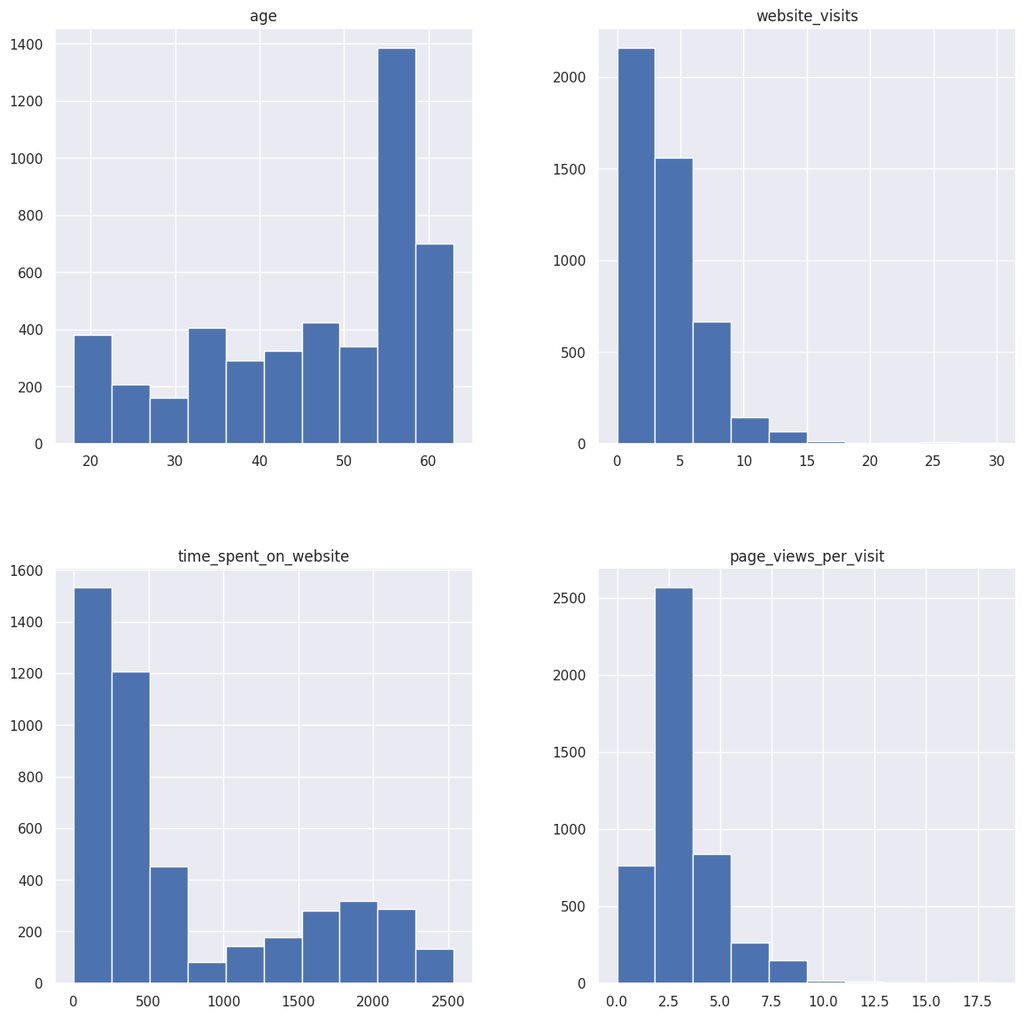

```python
#Creating histograms
df[num_col].hist(figsize=(14,14))
plt.show()
```

We see a spike in the number of people spending 0 time on the phone as we trend below 700 minutes. Above 700 minutes, there appers to be some normalization of the curve. I am assuming that the spike towards 0 is representative of those using other channels such as the phone or email. This also may represent that there is a minimum amount of time required to spend on the website to create a sale at around 1000 minutes.

```python
#Find if time spent on website less that 700 has many sales
df.query('time_spent_on_website < 700 and status==1')
```

|  | age | current_occupation | first_interaction | profile_completed | website_visits | time_spent_on_website | page_views_per_visit | last_activity | print_media_type1 | print_media_type2 | digital_media | educational_channels | referral | status |
| --- | --- | --- | --- | --- | --- | --- | --- | --- | --- | --- | --- | --- | --- | --- |
| 3 | 53 | Unemployed | Website | High | 4 | 464 | 2.057 | Website Activity | No | No | No | No | No | 1 |
| 6 | 56 | Professional | Mobile App | Medium | 13 | 625 | 2.015 | Website Activity | No | No | Yes | No | No | 1 |
| 10 | 52 | Professional | Website | Medium | 2 | 433 | 2.140 | Email Activity | No | No | No | No | No | 1 |
| 11 | 57 | Professional | Website | High | 3 | 616 | 3.485 | Website Activity | Yes | Yes | No | No | No | 1 |
| 34 | 55 | Professional | Website | High | 2 | 552 | 1.885 | Email Activity | No | No | No | No | No | 1 |
| ... | ... | ... | ... | ... | ... | ... | ... | ... | ... | ... | ... | ... | ... | ... |
| 4555 | 58 | Unemployed | Website | High | 4 | 531 | 5.228 | Website Activity | No | No | No | No | No | 1 |
| 4574 | 62 | Unemployed | Website | High | 5 | 416 | 0.034 | Website Activity | No | No | No | No | No | 1 |
| 4578 | 58 | Professional | Website | High | 0 | 0 | 0.000 | Email Activity | No | No | No | No | No | 1 |
| 4604 | 58 | Professional | Website | Medium | 2 | 555 | 3.305 | Website Activity | No | No | No | No | No | 1 |
| 4609 | 58 | Professional | Website | High | 2 | 212 | 2.692 | Email Activity | No | No | No | No | No | 1 |

663 rows × 14 columns

```python
# find if time spent on website greater than 700 has many sales
df.query('time_spent_on_website > 700 and status==1')
```

|  | age | current_occupation | first_interaction | profile_completed | website_visits | time_spent_on_website | page_views_per_visit | last_activity | print_media_type1 | print_media_type2 | digital_media | educational_channels | referral | status |
| --- | --- | --- | --- | --- | --- | --- | --- | --- | --- | --- | --- | --- | --- | --- |
| 0 | 57 | Unemployed | Website | High | 7 | 1639 | 1.861 | Website Activity | Yes | No | Yes | No | No | 1 |
| 8 | 57 | Professional | Mobile App | High | 2 | 2231 | 2.194 | Phone Activity | No | No | Yes | No | No | 1 |
| 16 | 47 | Professional | Website | High | 3 | 1419 | 3.450 | Email Activity | No | No | Yes | No | Yes | 1 |
| 24 | 49 | Professional | Mobile App | High | 5 | 2293 | 3.233 | Email Activity | No | No | No | No | No | 1 |
| 25 | 46 | Professional | Website | Medium | 4 | 1842 | 2.110 | Email Activity | No | No | No | Yes | No | 1 |
| ... | ... | ... | ... | ... | ... | ... | ... | ... | ... | ... | ... | ... | ... | ... |
| 4571 | 54 | Professional | Website | High | 12 | 1513 | 5.703 | Email Activity | No | No | No | No | No | 1 |
| 4580 | 55 | Professional | Website | Medium | 3 | 2445 | 2.075 | Email Activity | No | No | No | No | No | 1 |
| 4583 | 49 | Professional | Website | Medium | 24 | 1039 | 2.064 | Email Activity | Yes | No | No | No | No | 1 |
| 4587 | 60 | Professional | Website | High | 2 | 1567 | 4.028 | Email Activity | No | No | No | No | No | 1 |
| 4588 | 60 | Professional | Mobile App | Medium | 1 | 2116 | 2.158 | Email Activity | No | No | No | No | No | 1 |

713 rows × 14 columns

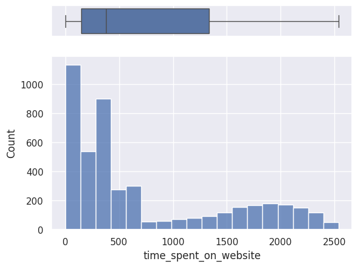

```python
f, (ax_box, ax_hist) = plt.subplots(2, sharex=True, gridspec_kw={"height_ratios": (.15, .85)})
sns.boxplot(df["time_spent_on_website"], orient="h", ax=ax_box)
sns.histplot(data=df, x="time_spent_on_website", ax=ax_hist)
ax_box.set(xlabel='')
plt.show()
```

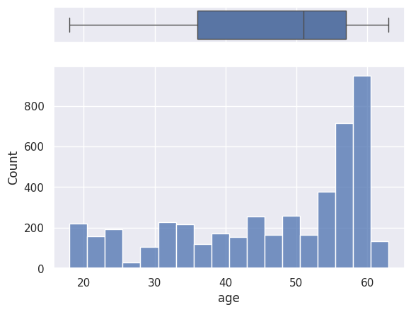

```python
f, (ax_box, ax_hist) = plt.subplots(2, sharex=True, gridspec_kw={"height_ratios": (.15, .85)})
sns.boxplot(df["age"], orient="h", ax=ax_box)
sns.histplot(data=df, x="age", ax=ax_hist)
ax_box.set(xlabel='')
plt.show()
```

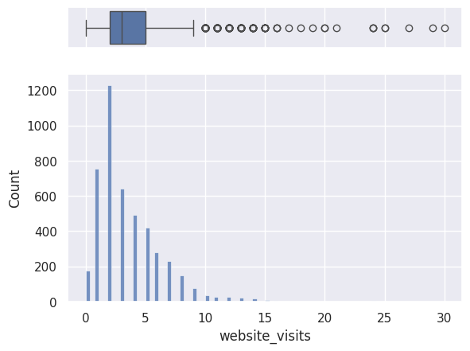

```python
f, (ax_box, ax_hist) = plt.subplots(2, sharex=True, gridspec_kw={"height_ratios": (.15, .85)})
sns.boxplot(df["website_visits"], orient="h", ax=ax_box)
sns.histplot(data=df, x="website_visits", ax=ax_hist)
ax_box.set(xlabel='')
plt.show()
```

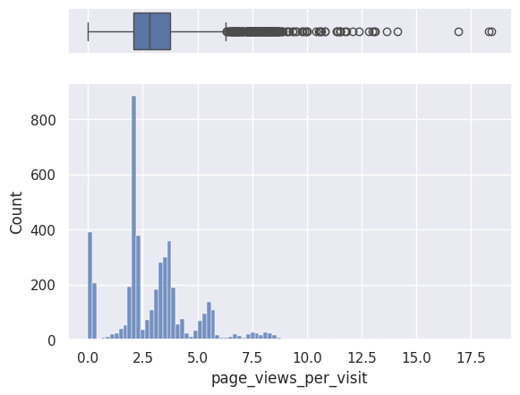

```python
f, (ax_box, ax_hist) = plt.subplots(2, sharex=True, gridspec_kw={"height_ratios": (.15, .85)})
sns.boxplot(df["page_views_per_visit"], orient="h", ax=ax_box)
sns.histplot(data=df, x="page_views_per_visit", ax=ax_hist)
ax_box.set(xlabel='')
plt.show()
```

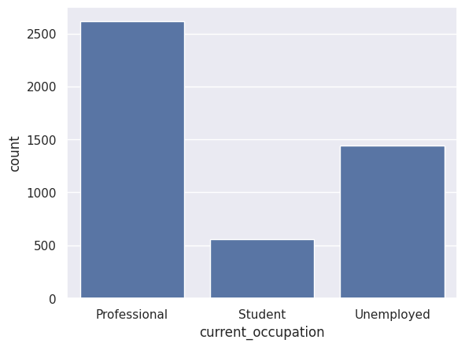

```python
sns.countplot(x=df['current_occupation'])
plt.show()
```

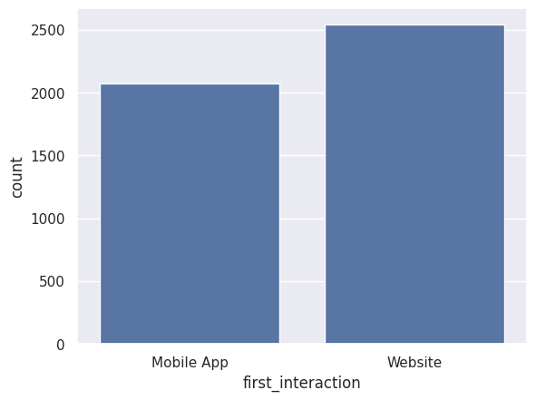

```python
sns.countplot(x=df['first_interaction'])
plt.show()
```

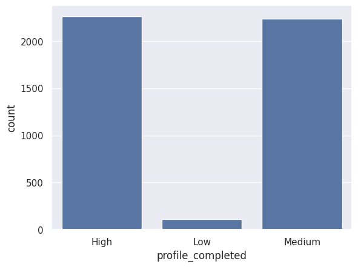

```python
sns.countplot(x=df['profile_completed'])
plt.show()
```

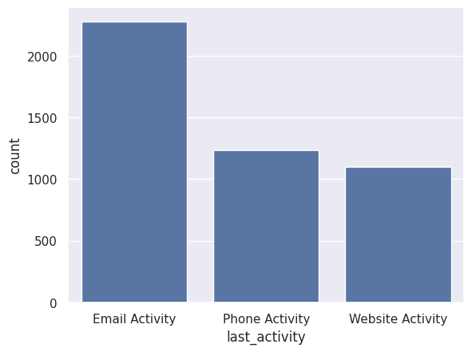

```python
sns.countplot(x=df['last_activity'])
plt.show()
```

```python
### print the % sub categories of each category
for i in category_col:
  print(df[i].value_counts(normalize=True))
  print('*'*40)
```

```
current_occupation
Professional    0.567216
Unemployed      0.312446
Student         0.120338
Name: proportion, dtype: float64
first_interaction
Website       0.551171
Mobile App    0.448829
Name: proportion, dtype: float64
profile_completed
High      0.490893
Medium    0.485906
Low       0.023200
Name: proportion, dtype: float64
last_activity
Email Activity      0.493929
Phone Activity      0.267563
Website Activity    0.238508
Name: proportion, dtype: float64
print_media_type1
No     0.892238
Yes    0.107762
Name: proportion, dtype: float64
print_media_type2
No     0.94948
Yes    0.05052
Name: proportion, dtype: float64
digital_media
No     0.885733
Yes    0.114267
Name: proportion, dtype: float64
educational_channels
No     0.847138
Yes    0.152862
Name: proportion, dtype: float64
referral
No     0.979835
Yes    0.020165
Name: proportion, dtype: float64
status
0    0.701431
1    0.298569
Name: proportion, dtype: float64
```

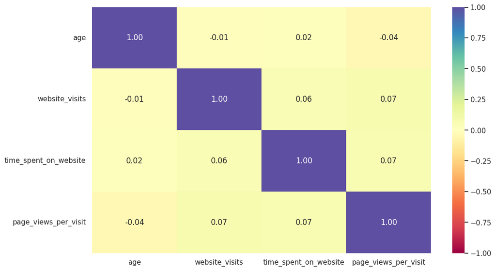

```python
cols_list=df.select_dtypes(include=np.number).columns.tolist()
plt.figure(figsize=(12,7))
sns.heatmap(df[cols_list].corr(), annot=True, vmin=-1, vmax=1, fmt=".2f", cmap="Spectral")
plt.show()
```

```python
#determine how many professionals made sales
df[category_col].query('current_occupation == "Professional" and status==1')
```

|  | current_occupation | first_interaction | profile_completed | last_activity | print_media_type1 | print_media_type2 | digital_media | educational_channels | referral | status |
| --- | --- | --- | --- | --- | --- | --- | --- | --- | --- | --- |
| 6 | Professional | Mobile App | Medium | Website Activity | No | No | Yes | No | No | 1 |
| 8 | Professional | Mobile App | High | Phone Activity | No | No | Yes | No | No | 1 |
| 10 | Professional | Website | Medium | Email Activity | No | No | No | No | No | 1 |
| 11 | Professional | Website | High | Website Activity | Yes | Yes | No | No | No | 1 |
| 16 | Professional | Website | High | Email Activity | No | No | Yes | No | Yes | 1 |
| ... | ... | ... | ... | ... | ... | ... | ... | ... | ... | ... |
| 4583 | Professional | Website | Medium | Email Activity | Yes | No | No | No | No | 1 |
| 4587 | Professional | Website | High | Email Activity | No | No | No | No | No | 1 |
| 4588 | Professional | Mobile App | Medium | Email Activity | No | No | No | No | No | 1 |
| 4604 | Professional | Website | Medium | Website Activity | No | No | No | No | No | 1 |
| 4609 | Professional | Website | High | Email Activity | No | No | No | No | No | 1 |

929 rows × 10 columns

```python
#determine how many Unemployed resulted in sales
df[category_col].query('current_occupation == "Unemployed" and status==1')
```

|  | current_occupation | first_interaction | profile_completed | last_activity | print_media_type1 | print_media_type2 | digital_media | educational_channels | referral | status |
| --- | --- | --- | --- | --- | --- | --- | --- | --- | --- | --- |
| 0 | Unemployed | Website | High | Website Activity | Yes | No | Yes | No | No | 1 |
| 3 | Unemployed | Website | High | Website Activity | No | No | No | No | No | 1 |
| 31 | Unemployed | Website | Medium | Email Activity | No | No | Yes | Yes | No | 1 |
| 57 | Unemployed | Website | Medium | Email Activity | No | No | No | No | No | 1 |
| 73 | Unemployed | Website | High | Phone Activity | No | No | No | No | No | 1 |
| ... | ... | ... | ... | ... | ... | ... | ... | ... | ... | ... |
| 4490 | Unemployed | Website | High | Email Activity | No | No | No | No | No | 1 |
| 4554 | Unemployed | Website | High | Email Activity | No | No | No | No | No | 1 |
| 4555 | Unemployed | Website | High | Website Activity | No | No | No | No | No | 1 |
| 4570 | Unemployed | Website | High | Website Activity | Yes | No | No | No | No | 1 |
| 4574 | Unemployed | Website | High | Website Activity | No | No | No | No | No | 1 |

383 rows × 10 columns

```python
#determine how many students resulted in sales
df[category_col].query('current_occupation == "Student" and status==1')
```

|  | current_occupation | first_interaction | profile_completed | last_activity | print_media_type1 | print_media_type2 | digital_media | educational_channels | referral | status |
| --- | --- | --- | --- | --- | --- | --- | --- | --- | --- | --- |
| 55 | Student | Website | Medium | Website Activity | No | No | No | Yes | No | 1 |
| 138 | Student | Website | High | Email Activity | No | No | No | No | No | 1 |
| 207 | Student | Website | High | Email Activity | Yes | No | No | No | No | 1 |
| 299 | Student | Mobile App | High | Email Activity | No | Yes | No | No | No | 1 |
| 319 | Student | Website | Medium | Email Activity | No | No | No | No | No | 1 |
| ... | ... | ... | ... | ... | ... | ... | ... | ... | ... | ... |
| 4345 | Student | Website | High | Website Activity | No | No | No | No | No | 1 |
| 4370 | Student | Website | High | Email Activity | No | No | No | No | Yes | 1 |
| 4418 | Student | Website | High | Website Activity | Yes | No | No | No | No | 1 |
| 4449 | Student | Website | High | Website Activity | No | No | No | Yes | No | 1 |
| 4468 | Student | Mobile App | Medium | Email Activity | No | No | No | No | Yes | 1 |

65 rows × 10 columns

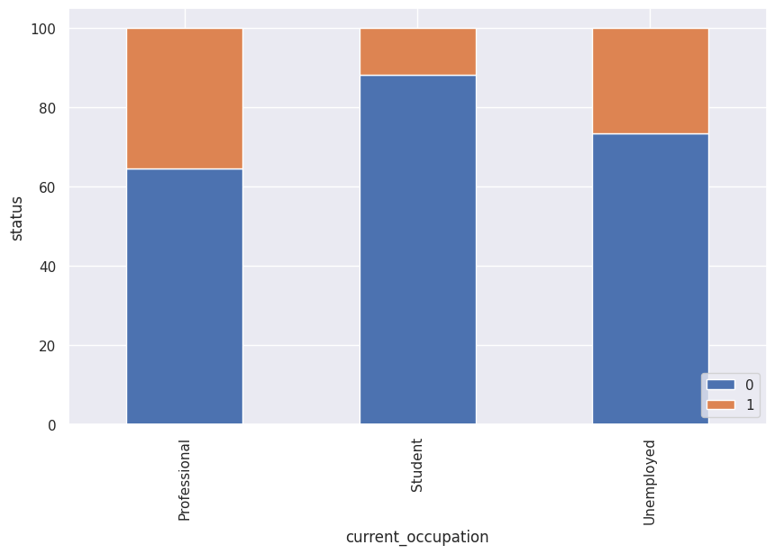

```python
def stacked_barplot(df, predictor, target, figsize=(10,6)):
  (pd.crosstab(df[predictor], df[target], normalize='index')*100).plot(kind='bar', figsize=figsize, stacked=True)
  plt.legend(loc="lower right")
  plt.ylabel(target)

stacked_barplot(df, "current_occupation", "status")
```

```python
#determine how many of each current_occupation there is and how many total interactions
for i in category_col:
  print(df[i].value_counts(normalize=False))
  print('*'*40)
```

```
current_occupation
Professional    2616
Unemployed      1441
Student          555
Name: count, dtype: int64
first_interaction
Website       2542
Mobile App    2070
Name: count, dtype: int64
profile_completed
High      2264
Medium    2241
Low        107
Name: count, dtype: int64
last_activity
Email Activity      2278
Phone Activity      1234
Website Activity    1100
Name: count, dtype: int64
print_media_type1
No     4115
Yes     497
Name: count, dtype: int64
print_media_type2
No     4379
Yes     233
Name: count, dtype: int64
digital_media
No     4085
Yes     527
Name: count, dtype: int64
educational_channels
No     3907
Yes     705
Name: count, dtype: int64
referral
No     4519
Yes      93
Name: count, dtype: int64
status
0    3235
1    1377
Name: count, dtype: int64
```

```python
#Determine how many first interactions via website resulted in sales
df[category_col].query('first_interaction == "Website" and status==1')
```

|  | current_occupation | first_interaction | profile_completed | last_activity | print_media_type1 | print_media_type2 | digital_media | educational_channels | referral | status |
| --- | --- | --- | --- | --- | --- | --- | --- | --- | --- | --- |
| 0 | Unemployed | Website | High | Website Activity | Yes | No | Yes | No | No | 1 |
| 3 | Unemployed | Website | High | Website Activity | No | No | No | No | No | 1 |
| 10 | Professional | Website | Medium | Email Activity | No | No | No | No | No | 1 |
| 11 | Professional | Website | High | Website Activity | Yes | Yes | No | No | No | 1 |
| 16 | Professional | Website | High | Email Activity | No | No | Yes | No | Yes | 1 |
| ... | ... | ... | ... | ... | ... | ... | ... | ... | ... | ... |
| 4580 | Professional | Website | Medium | Email Activity | No | No | No | No | No | 1 |
| 4583 | Professional | Website | Medium | Email Activity | Yes | No | No | No | No | 1 |
| 4587 | Professional | Website | High | Email Activity | No | No | No | No | No | 1 |
| 4604 | Professional | Website | Medium | Website Activity | No | No | No | No | No | 1 |
| 4609 | Professional | Website | High | Email Activity | No | No | No | No | No | 1 |

1159 rows × 10 columns

```python
#Determine how many first interactions via mobile app resulted in sales
df[category_col].query('first_interaction == "Mobile App" and status==1')
```

|  | current_occupation | first_interaction | profile_completed | last_activity | print_media_type1 | print_media_type2 | digital_media | educational_channels | referral | status |
| --- | --- | --- | --- | --- | --- | --- | --- | --- | --- | --- |
| 6 | Professional | Mobile App | Medium | Website Activity | No | No | Yes | No | No | 1 |
| 8 | Professional | Mobile App | High | Phone Activity | No | No | Yes | No | No | 1 |
| 24 | Professional | Mobile App | High | Email Activity | No | No | No | No | No | 1 |
| 51 | Professional | Mobile App | High | Email Activity | No | No | No | No | No | 1 |
| 72 | Professional | Mobile App | Medium | Email Activity | No | No | No | No | No | 1 |
| ... | ... | ... | ... | ... | ... | ... | ... | ... | ... | ... |
| 4425 | Unemployed | Mobile App | High | Website Activity | No | No | No | No | No | 1 |
| 4455 | Professional | Mobile App | Medium | Email Activity | No | No | No | No | No | 1 |
| 4468 | Student | Mobile App | Medium | Email Activity | No | No | No | No | Yes | 1 |
| 4528 | Professional | Mobile App | Medium | Website Activity | No | No | No | No | No | 1 |
| 4588 | Professional | Mobile App | Medium | Email Activity | No | No | No | No | No | 1 |

218 rows × 10 columns

Once the math is completed, we find that we close on approximately 46% (almost half) of first interactions via the wesite vs only 11% of first interactions via the mobile app. With products and company being the same, there may need to be some explorations into customer complains regarding the mobile app. Maybe a survey of user experience regarding both the website and the mobile app to determine what changes can be made to the app to create a similar experience to using the website.

```python
#determine the number of last activity via email resulted in sales
df[category_col].query('last_activity == "Email Activity" and status==1')
```

|  | current_occupation | first_interaction | profile_completed | last_activity | print_media_type1 | print_media_type2 | digital_media | educational_channels | referral | status |
| --- | --- | --- | --- | --- | --- | --- | --- | --- | --- | --- |
| 10 | Professional | Website | Medium | Email Activity | No | No | No | No | No | 1 |
| 16 | Professional | Website | High | Email Activity | No | No | Yes | No | Yes | 1 |
| 24 | Professional | Mobile App | High | Email Activity | No | No | No | No | No | 1 |
| 25 | Professional | Website | Medium | Email Activity | No | No | No | Yes | No | 1 |
| 31 | Unemployed | Website | Medium | Email Activity | No | No | Yes | Yes | No | 1 |
| ... | ... | ... | ... | ... | ... | ... | ... | ... | ... | ... |
| 4580 | Professional | Website | Medium | Email Activity | No | No | No | No | No | 1 |
| 4583 | Professional | Website | Medium | Email Activity | Yes | No | No | No | No | 1 |
| 4587 | Professional | Website | High | Email Activity | No | No | No | No | No | 1 |
| 4588 | Professional | Mobile App | Medium | Email Activity | No | No | No | No | No | 1 |
| 4609 | Professional | Website | High | Email Activity | No | No | No | No | No | 1 |

691 rows × 10 columns

```python
#determine the number of last activity via phone resulted in sales
df[category_col].query('last_activity == "Phone Activity" and status==1')
```

|  | current_occupation | first_interaction | profile_completed | last_activity | print_media_type1 | print_media_type2 | digital_media | educational_channels | referral | status |
| --- | --- | --- | --- | --- | --- | --- | --- | --- | --- | --- |
| 8 | Professional | Mobile App | High | Phone Activity | No | No | Yes | No | No | 1 |
| 60 | Professional | Website | High | Phone Activity | No | No | No | No | No | 1 |
| 73 | Unemployed | Website | High | Phone Activity | No | No | No | No | No | 1 |
| 102 | Professional | Website | Medium | Phone Activity | No | No | No | No | No | 1 |
| 132 | Unemployed | Website | High | Phone Activity | No | No | Yes | No | No | 1 |
| ... | ... | ... | ... | ... | ... | ... | ... | ... | ... | ... |
| 4484 | Professional | Website | Low | Phone Activity | No | No | No | No | No | 1 |
| 4485 | Professional | Website | High | Phone Activity | No | No | No | No | No | 1 |
| 4499 | Professional | Website | High | Phone Activity | Yes | No | No | No | No | 1 |
| 4538 | Professional | Website | High | Phone Activity | No | No | No | No | No | 1 |
| 4548 | Professional | Website | High | Phone Activity | No | No | No | No | No | 1 |

263 rows × 10 columns

```python
#determine the number of last activity via website chat resulted in sales
df[category_col].query('last_activity == "Website Activity" and status==1')
```

|  | current_occupation | first_interaction | profile_completed | last_activity | print_media_type1 | print_media_type2 | digital_media | educational_channels | referral | status |
| --- | --- | --- | --- | --- | --- | --- | --- | --- | --- | --- |
| 0 | Unemployed | Website | High | Website Activity | Yes | No | Yes | No | No | 1 |
| 3 | Unemployed | Website | High | Website Activity | No | No | No | No | No | 1 |
| 6 | Professional | Mobile App | Medium | Website Activity | No | No | Yes | No | No | 1 |
| 11 | Professional | Website | High | Website Activity | Yes | Yes | No | No | No | 1 |
| 53 | Professional | Website | High | Website Activity | No | No | No | Yes | No | 1 |
| ... | ... | ... | ... | ... | ... | ... | ... | ... | ... | ... |
| 4528 | Professional | Mobile App | Medium | Website Activity | No | No | No | No | No | 1 |
| 4555 | Unemployed | Website | High | Website Activity | No | No | No | No | No | 1 |
| 4570 | Unemployed | Website | High | Website Activity | Yes | No | No | No | No | 1 |
| 4574 | Unemployed | Website | High | Website Activity | No | No | No | No | No | 1 |
| 4604 | Professional | Website | Medium | Website Activity | No | No | No | No | No | 1 |

423 rows × 10 columns

Email activity generates the most sales with 691 sales generated. Website activity was second with 423 sales, and phone activity was last with 263 sales.

As far as conversion rates, website activity led with a 38% conversion rate. Email was second at 30%, and phone conversion rate was last at 21%

```python
#determine the number of sales generated by print media 1
df[category_col].query('print_media_type1 == "Yes" and status==1')
```

|  | current_occupation | first_interaction | profile_completed | last_activity | print_media_type1 | print_media_type2 | digital_media | educational_channels | referral | status |
| --- | --- | --- | --- | --- | --- | --- | --- | --- | --- | --- |
| 0 | Unemployed | Website | High | Website Activity | Yes | No | Yes | No | No | 1 |
| 11 | Professional | Website | High | Website Activity | Yes | Yes | No | No | No | 1 |
| 56 | Professional | Website | High | Website Activity | Yes | No | No | Yes | No | 1 |
| 59 | Professional | Website | High | Email Activity | Yes | No | No | No | No | 1 |
| 90 | Professional | Website | High | Website Activity | Yes | No | No | Yes | No | 1 |
| ... | ... | ... | ... | ... | ... | ... | ... | ... | ... | ... |
| 4469 | Professional | Website | High | Website Activity | Yes | No | No | No | No | 1 |
| 4486 | Professional | Website | High | Email Activity | Yes | No | No | No | No | 1 |
| 4499 | Professional | Website | High | Phone Activity | Yes | No | No | No | No | 1 |
| 4570 | Unemployed | Website | High | Website Activity | Yes | No | No | No | No | 1 |
| 4583 | Professional | Website | Medium | Email Activity | Yes | No | No | No | No | 1 |

159 rows × 10 columns

```python
#Provide conversion rate for print media type 1... total number to divide by recovered from above query
media1conv=len(df[category_col].query('print_media_type1 == "Yes" and status==1'))
print(media1conv/497)
```

```
0.3199195171026157
```

```python
#determine the number of sales generated by print media 2
df[category_col].query('print_media_type2 == "Yes" and status==1')
```

|  | current_occupation | first_interaction | profile_completed | last_activity | print_media_type1 | print_media_type2 | digital_media | educational_channels | referral | status |
| --- | --- | --- | --- | --- | --- | --- | --- | --- | --- | --- |
| 11 | Professional | Website | High | Website Activity | Yes | Yes | No | No | No | 1 |
| 76 | Professional | Website | High | Website Activity | No | Yes | No | No | No | 1 |
| 114 | Professional | Website | High | Email Activity | No | Yes | No | No | No | 1 |
| 139 | Professional | Website | High | Email Activity | No | Yes | No | No | No | 1 |
| 284 | Professional | Website | High | Email Activity | No | Yes | No | No | No | 1 |
| ... | ... | ... | ... | ... | ... | ... | ... | ... | ... | ... |
| 4293 | Professional | Website | Medium | Website Activity | No | Yes | No | Yes | No | 1 |
| 4316 | Professional | Mobile App | Medium | Website Activity | No | Yes | Yes | No | No | 1 |
| 4357 | Professional | Website | Medium | Email Activity | No | Yes | No | Yes | No | 1 |
| 4466 | Professional | Website | Medium | Email Activity | No | Yes | No | No | No | 1 |
| 4506 | Professional | Website | High | Email Activity | No | Yes | No | No | No | 1 |

75 rows × 10 columns

```python
#Provide conversion rate for print media type 2... total number to divide by recovered from above query
media2conv=len(df[category_col].query('print_media_type2 == "Yes" and status==1'))
print(media2conv/233)
```

```
0.3218884120171674
```

```python
#determine the number of sales generated by digital media
df[category_col].query('digital_media == "Yes" and status==1')
```

|  | current_occupation | first_interaction | profile_completed | last_activity | print_media_type1 | print_media_type2 | digital_media | educational_channels | referral | status |
| --- | --- | --- | --- | --- | --- | --- | --- | --- | --- | --- |
| 0 | Unemployed | Website | High | Website Activity | Yes | No | Yes | No | No | 1 |
| 6 | Professional | Mobile App | Medium | Website Activity | No | No | Yes | No | No | 1 |
| 8 | Professional | Mobile App | High | Phone Activity | No | No | Yes | No | No | 1 |
| 16 | Professional | Website | High | Email Activity | No | No | Yes | No | Yes | 1 |
| 31 | Unemployed | Website | Medium | Email Activity | No | No | Yes | Yes | No | 1 |
| ... | ... | ... | ... | ... | ... | ... | ... | ... | ... | ... |
| 4369 | Unemployed | Website | High | Email Activity | No | No | Yes | No | No | 1 |
| 4411 | Professional | Website | Medium | Email Activity | No | No | Yes | No | No | 1 |
| 4421 | Professional | Website | Medium | Website Activity | No | No | Yes | No | No | 1 |
| 4423 | Professional | Website | High | Email Activity | No | No | Yes | No | No | 1 |
| 4445 | Unemployed | Website | High | Email Activity | No | No | Yes | No | No | 1 |

168 rows × 10 columns

```python
#Provide conversion rate for digital media... total number to divide by recovered from above query
digitalconv=len(df[category_col].query('digital_media == "Yes" and status==1'))
print(digitalconv/527)
```

```
0.3187855787476281
```

```python
#determine the number of sales generated by educational channels
df[category_col].query('educational_channels == "Yes" and status==1')
```

|  | current_occupation | first_interaction | profile_completed | last_activity | print_media_type1 | print_media_type2 | digital_media | educational_channels | referral | status |
| --- | --- | --- | --- | --- | --- | --- | --- | --- | --- | --- |
| 25 | Professional | Website | Medium | Email Activity | No | No | No | Yes | No | 1 |
| 31 | Unemployed | Website | Medium | Email Activity | No | No | Yes | Yes | No | 1 |
| 53 | Professional | Website | High | Website Activity | No | No | No | Yes | No | 1 |
| 55 | Student | Website | Medium | Website Activity | No | No | No | Yes | No | 1 |
| 56 | Professional | Website | High | Website Activity | Yes | No | No | Yes | No | 1 |
| ... | ... | ... | ... | ... | ... | ... | ... | ... | ... | ... |
| 4407 | Professional | Website | High | Email Activity | No | No | No | Yes | No | 1 |
| 4417 | Unemployed | Website | Medium | Website Activity | No | No | No | Yes | No | 1 |
| 4420 | Unemployed | Website | High | Email Activity | No | No | No | Yes | No | 1 |
| 4449 | Student | Website | High | Website Activity | No | No | No | Yes | No | 1 |
| 4550 | Professional | Website | Medium | Email Activity | No | No | No | Yes | Yes | 1 |

197 rows × 10 columns

```python
#Provide conversion rate for educational channels... total number to divide by recovered from above query
educonv=len(df[category_col].query('educational_channels == "Yes" and status==1'))
print(educonv/705)
```

```
0.2794326241134752
```

```python
#determine the number of sales generated by referrals
df[category_col].query('referral == "Yes" and status==1')
```

|  | current_occupation | first_interaction | profile_completed | last_activity | print_media_type1 | print_media_type2 | digital_media | educational_channels | referral | status |
| --- | --- | --- | --- | --- | --- | --- | --- | --- | --- | --- |
| 16 | Professional | Website | High | Email Activity | No | No | Yes | No | Yes | 1 |
| 52 | Professional | Website | High | Email Activity | No | No | No | No | Yes | 1 |
| 253 | Professional | Mobile App | Medium | Website Activity | No | No | No | No | Yes | 1 |
| 306 | Professional | Website | High | Website Activity | Yes | No | Yes | Yes | Yes | 1 |
| 388 | Professional | Mobile App | High | Phone Activity | Yes | No | No | No | Yes | 1 |
| ... | ... | ... | ... | ... | ... | ... | ... | ... | ... | ... |
| 4368 | Professional | Website | High | Email Activity | No | No | No | No | Yes | 1 |
| 4370 | Student | Website | High | Email Activity | No | No | No | No | Yes | 1 |
| 4468 | Student | Mobile App | Medium | Email Activity | No | No | No | No | Yes | 1 |
| 4476 | Professional | Website | High | Email Activity | No | No | No | No | Yes | 1 |
| 4550 | Professional | Website | Medium | Email Activity | No | No | No | Yes | Yes | 1 |

63 rows × 10 columns

```python
#Provide conversion rate for referrals... total number to divide by recovered from above query
referralconv=len(df[category_col].query('referral == "Yes" and status==1'))
print(referralconv/93)
```

```
0.6774193548387096
```

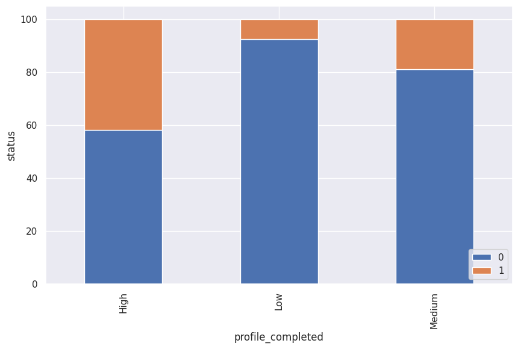

```python
### Defining the stacked_barplot() function and running comparison on profile completed/status to determine impact of profile completeness on conversion
def stacked_barplot(data,predictor,target,figsize=(10,6)):
  (pd.crosstab(data[predictor],data[target],normalize='index')*100).plot(kind='bar',figsize=figsize,stacked=True)
  plt.legend(loc="lower right")
  plt.ylabel(target)

stacked_barplot(df, "profile_completed", "status")
```

```python
df.columns  ## checking data
```

```
Index(['age', 'current_occupation', 'first_interaction', 'profile_completed',
       'website_visits', 'time_spent_on_website', 'page_views_per_visit',
       'last_activity', 'print_media_type1', 'print_media_type2',
       'digital_media', 'educational_channels', 'referral', 'status'],
      dtype='object')
```

```python
df.info()   ### checking data
```

```
<class 'pandas.core.frame.DataFrame'>
RangeIndex: 4612 entries, 0 to 4611
Data columns (total 14 columns):
 #   Column                 Non-Null Count  Dtype
---  ------                 --------------  -----
 0   age                    4612 non-null   int64
 1   current_occupation     4612 non-null   category
 2   first_interaction      4612 non-null   category
 3   profile_completed      4612 non-null   category
 4   website_visits         4612 non-null   int64
 5   time_spent_on_website  4612 non-null   int64
 6   page_views_per_visit   4612 non-null   float64
 7   last_activity          4612 non-null   category
 8   print_media_type1      4612 non-null   category
 9   print_media_type2      4612 non-null   category
 10  digital_media          4612 non-null   category
 11  educational_channels   4612 non-null   category
 12  referral               4612 non-null   category
 13  status                 4612 non-null   category
dtypes: category(10), float64(1), int64(3)
memory usage: 190.5 KB
```

```python
for column in category_col:
  df[column]=df[column].astype('category')
### converting dtype to category and checking data
df.info()
```

```
<class 'pandas.core.frame.DataFrame'>
RangeIndex: 4612 entries, 0 to 4611
Data columns (total 14 columns):
 #   Column                 Non-Null Count  Dtype
---  ------                 --------------  -----
 0   age                    4612 non-null   int64
 1   current_occupation     4612 non-null   category
 2   first_interaction      4612 non-null   category
 3   profile_completed      4612 non-null   category
 4   website_visits         4612 non-null   int64
 5   time_spent_on_website  4612 non-null   int64
 6   page_views_per_visit   4612 non-null   float64
 7   last_activity          4612 non-null   category
 8   print_media_type1      4612 non-null   category
 9   print_media_type2      4612 non-null   category
 10  digital_media          4612 non-null   category
 11  educational_channels   4612 non-null   category
 12  referral               4612 non-null   category
 13  status                 4612 non-null   category
dtypes: category(10), float64(1), int64(3)
memory usage: 190.5 KB
```

```python
df.info()   ### checking data structure
```

```
<class 'pandas.core.frame.DataFrame'>
RangeIndex: 4612 entries, 0 to 4611
Data columns (total 14 columns):
 #   Column                 Non-Null Count  Dtype
---  ------                 --------------  -----
 0   age                    4612 non-null   int64
 1   current_occupation     4612 non-null   category
 2   first_interaction      4612 non-null   category
 3   profile_completed      4612 non-null   category
 4   website_visits         4612 non-null   int64
 5   time_spent_on_website  4612 non-null   int64
 6   page_views_per_visit   4612 non-null   float64
 7   last_activity          4612 non-null   category
 8   print_media_type1      4612 non-null   category
 9   print_media_type2      4612 non-null   category
 10  digital_media          4612 non-null   category
 11  educational_channels   4612 non-null   category
 12  referral               4612 non-null   category
 13  status                 4612 non-null   category
dtypes: category(10), float64(1), int64(3)
memory usage: 190.5 KB
```

```python
df ### checking how data is now constructed
```

|  | age | current_occupation | first_interaction | profile_completed | website_visits | time_spent_on_website | page_views_per_visit | last_activity | print_media_type1 | print_media_type2 | digital_media | educational_channels | referral | status |
| --- | --- | --- | --- | --- | --- | --- | --- | --- | --- | --- | --- | --- | --- | --- |
| 0 | 57 | Unemployed | Website | High | 7 | 1639 | 1.861 | Website Activity | Yes | No | Yes | No | No | 1 |
| 1 | 56 | Professional | Mobile App | Medium | 2 | 83 | 0.320 | Website Activity | No | No | No | Yes | No | 0 |
| 2 | 52 | Professional | Website | Medium | 3 | 330 | 0.074 | Website Activity | No | No | Yes | No | No | 0 |
| 3 | 53 | Unemployed | Website | High | 4 | 464 | 2.057 | Website Activity | No | No | No | No | No | 1 |
| 4 | 23 | Student | Website | High | 4 | 600 | 16.914 | Email Activity | No | No | No | No | No | 0 |
| ... | ... | ... | ... | ... | ... | ... | ... | ... | ... | ... | ... | ... | ... | ... |
| 4607 | 35 | Unemployed | Mobile App | Medium | 15 | 360 | 2.170 | Phone Activity | No | No | No | Yes | No | 0 |
| 4608 | 55 | Professional | Mobile App | Medium | 8 | 2327 | 5.393 | Email Activity | No | No | No | No | No | 0 |
| 4609 | 58 | Professional | Website | High | 2 | 212 | 2.692 | Email Activity | No | No | No | No | No | 1 |
| 4610 | 57 | Professional | Mobile App | Medium | 1 | 154 | 3.879 | Website Activity | Yes | No | No | No | No | 0 |
| 4611 | 55 | Professional | Website | Medium | 4 | 2290 | 2.075 | Phone Activity | No | No | No | No | No | 0 |

4612 rows × 14 columns

```python
### Creating metric function
def metrics_score(actual, predicted):
    print(classification_report(actual, predicted))

    cm=confusion_matrix(actual, predicted)
    plt.figure(figsize=(8,5))

    sns.heatmap(cm, annot=True, fmt='2f', xticklabels=['Not Converted', 'Converted'], yticklabels=['Not Converted', 'Converted'])
    plt.ylabel('Actual')
    plt.xlabel('Predicted')
    plt.show()
```

## Building a Decision Tree model

```python
### it is most important to properly predict the conversion.  It will be unacceptable to have too many predictions of sales that don't convert, while a prediction of a non sale that does will be an accepted plus
### For this, we want Precision to be maximized

#splitting data into 70% train and 30% test sets
X_train, X_test, y_train, y_test= train_test_split(X, Y, test_size=0.3, random_state=1, stratify = Y)

####  create dummy list
to_get_dummies_for = ['current_occupation', 'first_interaction', 'profile_completed', 'last_activity', 'print_media_type1', 'print_media_type2', 'digital_media', 'educational_channels', 'referral', 'status']
df1=pd.DataFrame(df.drop(columns=['age', 'website_visits', 'time_spent_on_website', 'page_views_per_visit']))

#### creating dummy variables
df1=pd.get_dummies(data=df1, columns=to_get_dummies_for, drop_first=True)

###Mapping referral and status
dict_referral={'1': 1, '0' : 0}
dict_status= {'1': 1, '0' : 0}

###Separating the independent variables (x) and the dependent variable (Y)
Y=df1.status_1
X=df1.drop(columns=['status_1'])


#scaling the data
sc=StandardScaler()

for column in X_train.columns:
    if X_train[column].dtype == "object":
        print(f"Column '{column}' contains non-numeric values.")

#Fit_transform on train data
sc=StandardScaler()
X_train_scaled=sc.fit_transform(X_train)
X_train_scaled=pd.DataFrame(X_train_scaled, columns=X.columns)

##Transform on test data
x_test_scaled=sc.transform(X_test)
x_test_scaled=pd.DataFrame(x_test_scaled, columns=X.columns)

##Building Decision Tree Model
dt=DecisionTreeClassifier(class_weight = {0:0.17, 1:0.83}, random_state=1)

###Fitting decision tree model
dt.fit(X_train, y_train)
```

```
DecisionTreeClassifier(class_weight={0: 0.17, 1: 0.83}, random_state=1)
```

```
              precision    recall  f1-score   support

       False       0.94      0.72      0.81      2264
        True       0.57      0.89      0.69       964

    accuracy                           0.77      3228
   macro avg       0.75      0.80      0.75      3228
weighted avg       0.83      0.77      0.78      3228
```

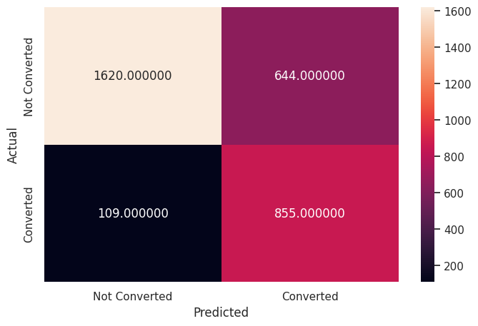

```python
### checking performance on the training dataset
y_train_pred_dt=dt.predict(X_train)
metrics_score(y_train, y_train_pred_dt)
```

```
              precision    recall  f1-score   support

       False       0.88      0.70      0.78       971
        True       0.53      0.78      0.63       413

    accuracy                           0.73      1384
   macro avg       0.71      0.74      0.71      1384
weighted avg       0.78      0.73      0.74      1384
```

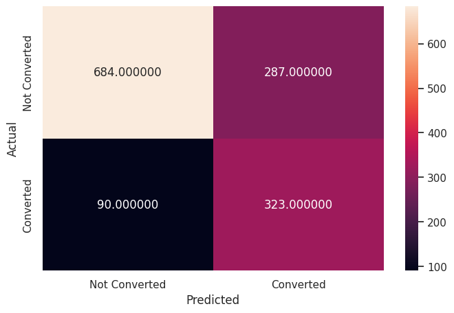

```python
#### checking performance on test data set
y_test_pred_dt=dt.predict(X_test)
metrics_score(y_test, y_test_pred_dt)
```

```python
confusion_matrix(y_test, y_test_pred_dt)   #another way of doing confusion matrix
```

```
array([[684, 287],
       [ 90, 323]])
```

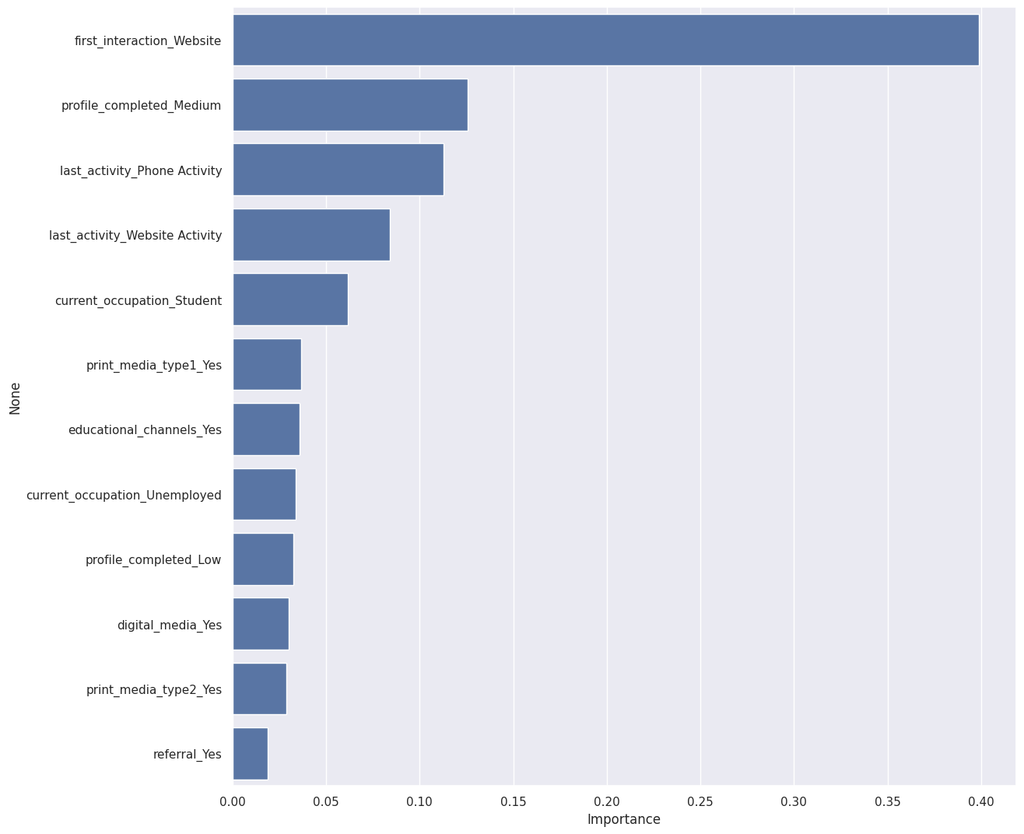

```python
### plot feature importance
importances = dt.feature_importances_

columns = X.columns

importance_df = pd.DataFrame(importances, index = columns, columns = ['Importance']).sort_values(by = 'Importance', ascending = False)

plt.figure(figsize = (13, 13))

sns.barplot(x=importance_df.Importance, y=importance_df.index)
```